# Assignment06_Practical

## Important instruction

For programming exercises that only editing, only edit the code as shown in the following format.

```
##############################################

#Edit the following code

var1 = 3
var2 = 4
print(var1 + var4)

##############################################
```

You are open to experimenting with the other parts of code but you will only be awarded points if the question asked is answered which only needs finishing or making changes to the code in the above specified format.

## Question 7: Visualising Classification Decision Trees

#### Step 3: Split the Dataset

- Divide the dataset into training and testing sets using `train_test_split()`, with an 80-20 split and a random state of 99.

#### Step 4: Initialize and Train the Classifier

- Initialize the `DecisionTreeClassifier` with a random state of 99.
- Train the classifier on the training data.

#### Step 5: Visualize the Decision Tree

- Create a basic visualization of the decision tree. As shown below.

[figure not shown]

For more information, refer to the following resources:

- https://scikit-learn.org/stable/modules/generated/sklearn.datasets.load_iris.html
- https://scikit-learn.org/stable/modules/generated/sklearn.tree.DecisionTreeClassifier.html
- https://matplotlib.org/stable/api/_as_gen/matplotlib.pyplot.subplots.html
- https://scikit-learn.org/stable/modules/generated/sklearn.tree.plot_tree.html

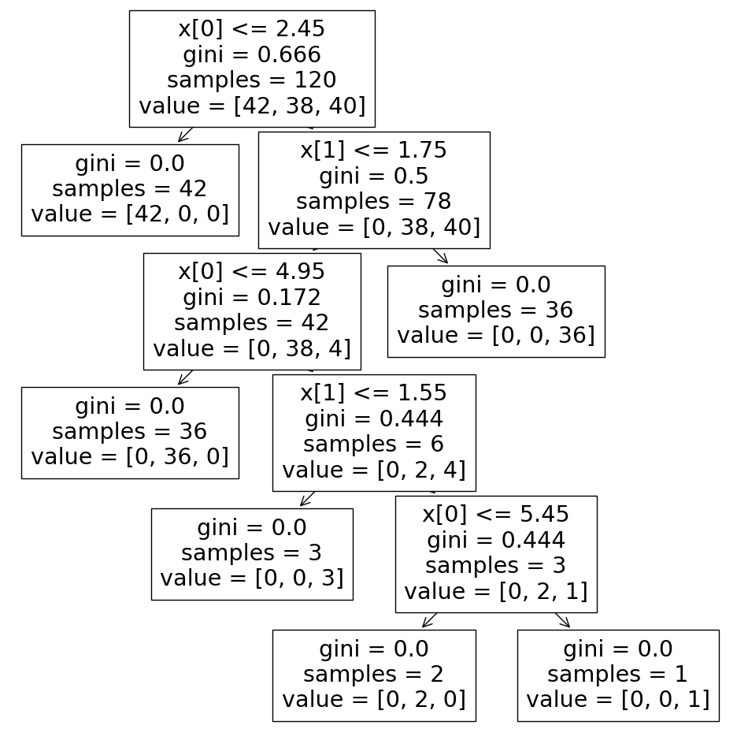

```python
#Write your code here
from sklearn.datasets import load_iris
from sklearn.model_selection import train_test_split
from sklearn.tree import DecisionTreeClassifier
from sklearn import tree
import matplotlib.pyplot as plt

iris = load_iris()
X = iris.data[:, 2:] # petal length and width
y = iris.target

Xtrain, Xtest, ytrain, ytest = train_test_split(X, y, test_size=0.2, random_state=99)

tree_clf = DecisionTreeClassifier(random_state=99)
tree_clf.fit(Xtrain, ytrain)

fig, ax = plt.subplots(figsize=(12, 12))
tree.plot_tree(tree_clf, filled=False, ax=ax)
plt.show()
```

## Question 8: Regression Decision Tree

#### Step 1: Import Required Libraries

#### Step 2: Load and Preprocess the Data

- Use this data: https://raw.githubusercontent.com/KrishnaTejaJ/datasets-CSCI-B455/main/assignment6/data-rdt.csv

#### Step 3: Split the Data:

- The data is split into training and testing sets, with 20% reserved for testing. The random state is set to 99.

#### Step 4: Train the Decision Tree Regressor:

- A `DecisionTreeRegressor` is instantiated with a maximum depth and then trained on the training data. Choose a max_depth value that will generate the same plot as below. The range of max_depth values that you could experiment is from 1 to 5.

[figure not shown]

#### Step 5: Evaluate the Model:

- The model makes predictions on the test set, and the Mean Squared Error (MSE) is calculated to evaluate the model's accuracy. The MSE is printed to the console.

#### Step 6: Visualize the Results:

- Replicate the plot that was shown above.

For more information, refer to the following resources:

- https://scikit-learn.org/stable/modules/generated/sklearn.tree.DecisionTreeRegressor.html
- https://matplotlib.org/stable/api/_as_gen/matplotlib.pyplot.subplots.html

```
Mean Squared Error: 0.015499944200849373
```

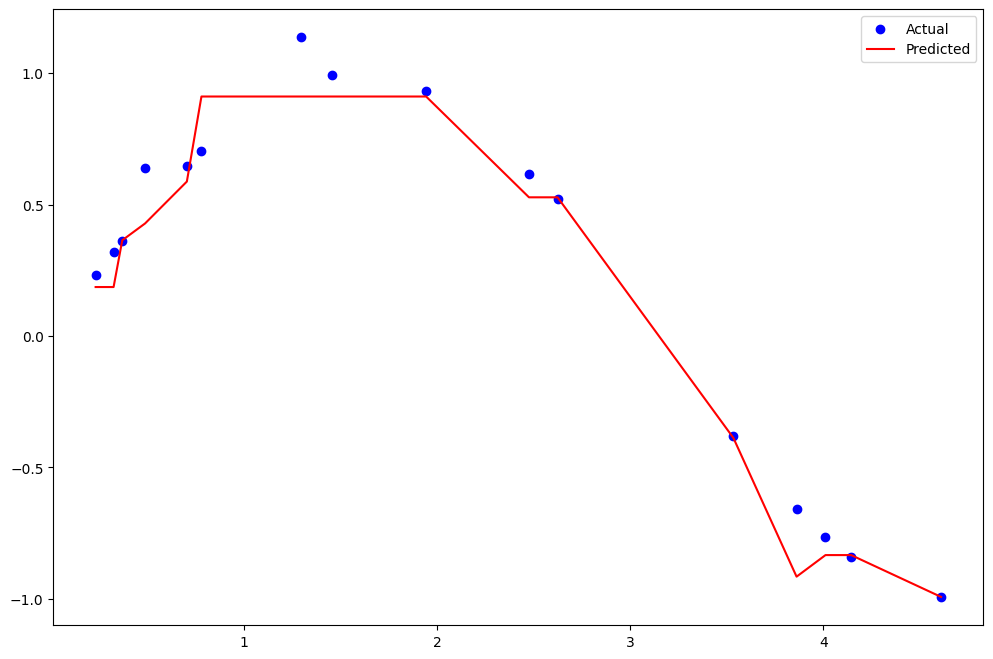

```python
#Write your code here
import pandas as pd
import numpy as np
import matplotlib.pyplot as plt
from sklearn.tree import DecisionTreeRegressor
from sklearn.model_selection import train_test_split
from sklearn.metrics import mean_squared_error

data = pd.read_csv('https://raw.githubusercontent.com/KrishnaTejaJ/datasets-CSCI-B455/main/assignment6/data-rdt.csv')
X = data['X'].values.reshape(-1, 1)
y = data['y']
X_train, X_test, y_train, y_test = train_test_split(X, y, test_size=0.2, random_state=99)

regressor = DecisionTreeRegressor(max_depth=5)
regressor.fit(X_train, y_train)

y_pred = regressor.predict(X_test)
mse = mean_squared_error(y_test, y_pred)
print(f'Mean Squared Error: {mse}')
sort_idx = X_test.flatten().argsort()
X_test_sorted = X_test.flatten()[sort_idx]
y_pred_sorted = y_pred[sort_idx]

plt.figure(figsize=(12, 8))
plt.scatter(X_test, y_test, color='blue', label='Actual')
plt.plot(X_test_sorted, y_pred_sorted, color='red', label='Predicted')
plt.legend()
plt.show()
```

## Question 9: Comparing Linear Discriminant and Logistic Discriminant

The objective of this question is to implement and compare Linear Discriminant and Logistic Discriminant. Follow the given instructions below:

### Step 1: Load the Dataset

- Use this data: https://raw.githubusercontent.com/KrishnaTejaJ/datasets-CSCI-B455/main/assignment6/lin_log.csv

### Step 2: Split the Data

- Divide the dataset into two parts: one for training the models and the other for testing their performance. A common split ratio is 70% for training and 30% for testing. Use 99 as the random state value.

### Step 3: Preprocess the Data

- Perform any necessary data preprocessing steps, such as feature scaling. Standardizing the features so they have a mean of 0 and a standard deviation of 1 can help improve the performance of many machine learning algorithms.

### Step 4: Train Logistic Regression with Polynomial Features

- Enhance the Logistic Regression model by adding polynomial features, which allow the model to capture more complex relationships in the data. Use a degree of polynomial that you find suitable based on the complexity of your dataset.
- Train the enhanced Logistic Regression model on the training dataset.

### Step 5: Train Linear Discriminant Analysis (LDA)

- Train an LDA model on the training dataset. LDA tries to find a linear combination of features that best separates two or more classes of events.

### Step 6: Evaluate the Models

- Use the testing dataset to evaluate the performance of both trained models. Calculate metrics such as accuracy to understand how well each model performs.

### Step 7: Visualize Decision Boundaries

- Plot the decision boundaries for each model to visualize how they separate the classes in the dataset. Use the `plot_decision_boundaries` function for plotting the decision boundaries.

### Step 8: Compare and Interpret Results

- Compare the performance of the two models based on the accuracy metrics and the visualized decision boundaries.

For more information, refer to the following resources:

- Chapter **10. Linear Discrimination** of **Introduction to Machine Learning, 4th Edition, The MIT Press, 2020** by Ethem Alpaydin.
- https://scikit-learn.org/stable/modules/generated/sklearn.pipeline.Pipeline.html
- https://scikit-learn.org/stable/modules/generated/sklearn.linear_model.LogisticRegression.html
- https://scikit-learn.org/stable/modules/generated/sklearn.discriminant_analysis.LinearDiscriminantAnalysis.html
- https://scikit-learn.org/stable/modules/generated/sklearn.inspection.DecisionBoundaryDisplay.html
- https://scikit-learn.org/stable/auto_examples/ensemble/plot_voting_decision_regions.html
- https://www.introspective-mode.org/logistic-regression-or-discriminant-function-analysis/

```
Accuracy of Logistic Regression: 0.89
Accuracy of LDA: 0.8866666666666667
```

[figure not shown]

```python
import matplotlib.pyplot as plt

# Function to plot decision boundaries
def plot_decision_boundaries(X, y, model, title):
    h = .02  # step size in the mesh
    x_min, x_max = X[:, 0].min() - 1, X[:, 0].max() + 1
    y_min, y_max = X[:, 1].min() - 1, X[:, 1].max() + 1
    xx, yy = np.meshgrid(np.arange(x_min, x_max, h),
                         np.arange(y_min, y_max, h))

    Z = model.predict(np.c_[xx.ravel(), yy.ravel()])
    Z = Z.reshape(xx.shape)
    plt.contourf(xx, yy, Z, alpha=0.5, cmap=plt.cm.Spectral)
    plt.scatter(X[:, 0], X[:, 1], c=y, s=20, edgecolor='k', cmap=plt.cm.Spectral)
    plt.title(title)

##############################################
#Write your code from here
import pandas as pd
import numpy as np
from sklearn.preprocessing import StandardScaler
from sklearn.model_selection import train_test_split
from sklearn.linear_model import LogisticRegression
from sklearn.pipeline import make_pipeline
from sklearn.preprocessing import PolynomialFeatures
from sklearn.discriminant_analysis import LinearDiscriminantAnalysis
from sklearn.metrics import accuracy_score

data = pd.read_csv('https://raw.githubusercontent.com/KrishnaTejaJ/datasets-CSCI-B455/main/assignment6/lin_log.csv')
X = data[['Feature_1', 'Feature_2']].values
y = data['Target'].values

X_train, X_test, y_train, y_test = train_test_split(X, y, test_size=0.3, random_state=99)

scalar = StandardScaler()
Xscaled = scalar.fit_transform(X_train)
xtest_scaled = scalar.transform(X_test)

log_reg = LogisticRegression(random_state=99)
poly = PolynomialFeatures(degree=2)
logReg = make_pipeline(poly, log_reg)
logReg.fit(Xscaled, y_train)

lda = LinearDiscriminantAnalysis()
lda.fit(Xscaled, y_train)

y_pred_logReg = logReg.predict(xtest_scaled)
y_pred_lda = lda.predict(xtest_scaled)
print(f'Accuracy of Logistic Regression: {accuracy_score(y_test, y_pred_logReg)}')
print(f'Accuracy of LDA: {accuracy_score(y_test, y_pred_lda)}')

# plot_decision_boundaries(Xscaled, y_train, logReg, 'Logistic Regression')
# plot_decision_boundaries(Xscaled, y_train, lda, 'Linear Discriminant Analysis')
```

### **Answer the following question with a brief reasoning.**

After comparing the Linear Discriminant and Logistic Discriminant, which method do you think draws the most appropriate decision boundary and **why**?